# Project: Investigate a no show appointment data set

- Introduction
- Data Wrangling
- Exploratory Data Analysis
- Conclusions

## Introduction

The No-show-dataset contains a great amount of information about the medical appointment in Brazil. it has been created to show if the patient showed in his appointment or not.

A number of characteristics about the patient are included in each row:

ScheduledDay: tells us on what day the patient set up their appointment. Neighborhood: indicates the location of the hospital. Scholarship: indicates whether or not the patient is enrolled in the Brasilian welfare program Bolsa Família.

No-show: ‘No’ if the patient showed up to their appointment, and ‘Yes’ if they did not show up.

1-What factors are important for us to know in order to predict if a patient will show up for their scheduled appointment?

2- what are the ovarall percentage of patients showed in their appointments and who are not?

```python
# import the libraries needed to work in the project
import pandas as pd
import numpy as np
% matplotlib inline
import matplotlib.pyplot as plt
import seaborn as sns
#read the dataset using pandas
df = pd.read_csv('noshowapp.csv')
```

## Data Wrangling

### General Properties

```python
# use .info() to check the types of data, number of rows & columns and nulls etc...
df.info()
```

```
<class 'pandas.core.frame.DataFrame'>
RangeIndex: 110527 entries, 0 to 110526
Data columns (total 14 columns):
PatientId         110527 non-null float64
AppointmentID     110527 non-null int64
Gender            110527 non-null object
ScheduledDay      110527 non-null object
AppointmentDay    110527 non-null object
Age               110527 non-null int64
Neighbourhood     110527 non-null object
Scholarship       110527 non-null int64
Hipertension      110527 non-null int64
Diabetes          110527 non-null int64
Alcoholism        110527 non-null int64
Handcap           110527 non-null int64
SMS_received      110527 non-null int64
No-show           110527 non-null object
dtypes: float64(1), int64(8), object(5)
memory usage: 11.8+ MB
```

```python
# use .duplicated().sum() to check if there are duplicate in data
df.duplicated().sum()
```

```
0
```

```python
# use .describe() to generate descriptive statistics
df.describe()
```

|  | PatientId | AppointmentID | Age | Scholarship | Hipertension | Diabetes | Alcoholism | Handcap | SMS_received |
| --- | --- | --- | --- | --- | --- | --- | --- | --- | --- |
| count | 1.105270e+05 | 1.105270e+05 | 110527.000000 | 110527.000000 | 110527.000000 | 110527.000000 | 110527.000000 | 110527.000000 | 110527.000000 |
| mean | 1.474963e+14 | 5.675305e+06 | 37.088874 | 0.098266 | 0.197246 | 0.071865 | 0.030400 | 0.022248 | 0.321026 |
| std | 2.560949e+14 | 7.129575e+04 | 23.110205 | 0.297675 | 0.397921 | 0.258265 | 0.171686 | 0.161543 | 0.466873 |
| min | 3.921784e+04 | 5.030230e+06 | -1.000000 | 0.000000 | 0.000000 | 0.000000 | 0.000000 | 0.000000 | 0.000000 |
| 25% | 4.172614e+12 | 5.640286e+06 | 18.000000 | 0.000000 | 0.000000 | 0.000000 | 0.000000 | 0.000000 | 0.000000 |
| 50% | 3.173184e+13 | 5.680573e+06 | 37.000000 | 0.000000 | 0.000000 | 0.000000 | 0.000000 | 0.000000 | 0.000000 |
| 75% | 9.439172e+13 | 5.725524e+06 | 55.000000 | 0.000000 | 0.000000 | 0.000000 | 0.000000 | 0.000000 | 1.000000 |
| max | 9.999816e+14 | 5.790484e+06 | 115.000000 | 1.000000 | 1.000000 | 1.000000 | 1.000000 | 4.000000 | 1.000000 |

```python
# check how many patients that their ages are 0 and less
(df["Age"] <= 0).sum()
```

```
3540
```

```python
# use .head(1) to display only the first row of the dataset
df.head()
```

|  | PatientId | AppointmentID | Gender | ScheduledDay | AppointmentDay | Age | Neighbourhood | Scholarship | Hipertension | Diabetes | Alcoholism | Handcap | SMS_received | No-show |
| --- | --- | --- | --- | --- | --- | --- | --- | --- | --- | --- | --- | --- | --- | --- |
| 0 | 2.987250e+13 | 5642903 | F | 2016-04-29T18:38:08Z | 2016-04-29T00:00:00Z | 62 | JARDIM DA PENHA | 0 | 1 | 0 | 0 | 0 | 0 | No |
| 1 | 5.589978e+14 | 5642503 | M | 2016-04-29T16:08:27Z | 2016-04-29T00:00:00Z | 56 | JARDIM DA PENHA | 0 | 0 | 0 | 0 | 0 | 0 | No |
| 2 | 4.262962e+12 | 5642549 | F | 2016-04-29T16:19:04Z | 2016-04-29T00:00:00Z | 62 | MATA DA PRAIA | 0 | 0 | 0 | 0 | 0 | 0 | No |
| 3 | 8.679512e+11 | 5642828 | F | 2016-04-29T17:29:31Z | 2016-04-29T00:00:00Z | 8 | PONTAL DE CAMBURI | 0 | 0 | 0 | 0 | 0 | 0 | No |
| 4 | 8.841186e+12 | 5642494 | F | 2016-04-29T16:07:23Z | 2016-04-29T00:00:00Z | 56 | JARDIM DA PENHA | 0 | 1 | 1 | 0 | 0 | 0 | No |

## Summary of investigate

2- There are no nulls in the dataset

3- There are no duplicates

5- 3540 patint has a wrong ages( 0 , -1)

6- Thre is no need to analyze appointment id and patient id so it can be dropped

7- scheduledDay, AppointmentDay has a wrong data type need to change it to the (DateTime) type

8- there are some spelling mistakes in the columns names

9- No-show column should convert it to numbers so that can be used in plots

### Data Cleaning

#### 1- Fix zeros and -1 Ages

```python
# take the mean Ages then assign it to the 0 and -1 ages
FixAges = df['Age'].mean()
df[df["Age"] <= 0] = FixAges
```

#### 3- change ScheduledDay,AppointmentDay data types

```python
# use pd.to_datetime to convert the type to datetime type
df['ScheduledDay'] = pd.to_datetime(df['ScheduledDay'])
df['AppointmentDay']  = pd.to_datetime(df['AppointmentDay'])
```

#### 4- rename columns names

```python
df.rename(columns = {'No-show':'No_show', 'Hipertension':'Hypertension', 'Handcap':'Handicap'}, inplace = True)
```

#### 5- Change No_show column to numbers for easy handling

```python
df.No_show[df['No_show'] == "Yes"] = "0"
df.No_show[df['No_show'] == "No"] = "1"
df['No_show']  = pd.to_numeric(df['No_show'])
# sperete the No_ Show column to two new columns based
Show = df['No_show'] == 1
No_Show = df['No_show'] == 0
df['Showed'] = Show
df['Not_Showed'] = No_Show
```

#### 2- drop apointmentid and patintid columns

```python
df = df.drop(columns="AppointmentID")
df = df.drop(columns="PatientId")
#drop No_show column because it is not needed any more
df = df.drop(columns="No_show")
```

```python
# final cheack for the dataset before start exploring
df.head(1)
```

|  | Gender | ScheduledDay | AppointmentDay | Age | Neighbourhood | Scholarship | Hypertension | Diabetes | Alcoholism | Handicap | SMS_received | Showed | Not_Showed |
| --- | --- | --- | --- | --- | --- | --- | --- | --- | --- | --- | --- | --- | --- |
| 0 | F | 2016-04-29 18:38:08 | 2016-04-29 | 62.0 | JARDIM DA PENHA | 0.0 | 1.0 | 0.0 | 0.0 | 0.0 | 0.0 | True | False |

## Exploratory Data Analysis

### Q1-What factors are important for us to know in order to predict if a patient will show up for their scheduled appointment?

To know the most important factors that affect the patient shown in the scheduled appointment i will see the percentage of showing with each factor.

###### Alcoholism

```
The Relation Between Alcoholism And Being Shown In The Appointment Alcoholism
0.000000     0.797321
1.000000     0.798512
37.088874    0.000000
Name: Showed, dtype: float64
```

```
Text(0.5,1,'The persentage Between Alcoholics And Being Shown In The Appointment')
```

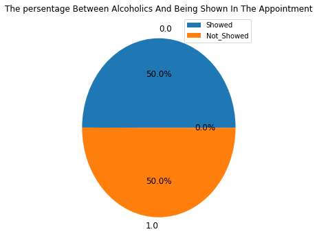

```python
# use a groupby function betwen Alcoholism and Showed to find the relation
E1 = df.groupby('Alcoholism')['Showed'].mean()
# calculate the percentage
percentage1 = E1 / E1.sum()*100
# print the relation
print("The Relation Between Alcoholism And Being Shown In The Appointment {}".format(E1))
# creat the piechart
pieChart = percentage1.plot.pie(figsize=(5,6), autopct='%1.1f%%', fontsize = 12);
# make the legend with manually entered parameters
plt.legend( ('Showed', 'Not_Showed'))
# remove the y labele because it is not needed
plt.ylabel("")
# make a title for the graph
plt.title("The persentage Between Alcoholics And Being Shown In The Appointment")
```

###### Scholarship

```
The Relation Between Scholarship And Being Shown In The Appointment Scholarship
0.000000     0.801316
1.000000     0.762143
37.088874    0.000000
Name: Showed, dtype: float64
```

```
Text(0.5,1,'The persentage Between Scholarship And Being Shown In The Appointment')
```

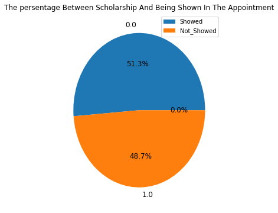

```python
# use a groupby function betwen Scholarship and Showed to find the relation
E2 = df.groupby('Scholarship')['Showed'].mean()
# calculate the percentage
percentage2 = E2 / E2.sum()*100
# print the relation
print("The Relation Between Scholarship And Being Shown In The Appointment {}".format(E2))
# creat the piechart
pieChart = percentage2.plot.pie(figsize=(5,6), autopct='%1.1f%%', fontsize = 12);
# make the legend with manually entered parameters
plt.legend( ('Showed', 'Not_Showed'))
# remove the y labele because it is not needed
plt.ylabel("")
# make a title for the graph
plt.title("The persentage Between Scholarship And Being Shown In The Appointment")
```

###### SMS_received

```
The Relation Between SMS_received And Being Shown In The Appointment SMS_received
0.000000     0.832712
1.000000     0.723348
37.088874    0.000000
Name: Showed, dtype: float64
```

```
Text(0.5,1,'The persentage Between SMS_received And Being Shown In The Appointment')
```

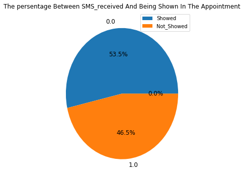

```python
# use a groupby function betwen SMS_received and Showed to find the relation
E3 = df.groupby('SMS_received')['Showed'].mean()
# calculate the percentage
percentage3 = E3 / E3.sum()*100
# print the relation
print("The Relation Between SMS_received And Being Shown In The Appointment {}".format(E3))
# creat the piechart
pieChart = percentage3.plot.pie(figsize=(5,6), autopct='%1.1f%%', fontsize = 12);
# make the legend with manually entered parameters
plt.legend( ('Showed', 'Not_Showed'))
# remove the y labele because it is not needed
plt.ylabel("")
# make a title for the graph
plt.title("The persentage Between SMS_received And Being Shown In The Appointment")
```

###### Gender

```
The Relation Between Gender And Being Shown In The Appointment Gender
37.08887421173107    0.000000
F                    0.796415
M                    0.799154
Name: Showed, dtype: float64
```

[output not shown]

[figure not shown]

```python
# use a groupby function betwen Gender and Showed to find the relation
E4 = df.groupby('Gender')['Showed'].mean()
# calculate the percentage
percentage4 = E4 / E4.sum()*100
# print the relation
print("The Relation Between Gender And Being Shown In The Appointment {}".format(E4))
# creat the piechart
pieChart = percentage4.plot.pie(figsize=(5,6), autopct='%1.1f%%', fontsize = 12);
# make the legend with manually entered parameters
plt.legend( ('Showed', 'Not_Showed'))
# remove the y labele because it is not needed
plt.ylabel("")
# make a title for the graph
plt.title("The persentage Between Gender And Being Shown In The Appointment")
```

###### Hypertension

```
The Relation Between Hypertension And Being Shown In The Appointment Hypertension
0.000000     0.789778
1.000000     0.826980
37.088874    0.000000
Name: Showed, dtype: float64
```

[output not shown]

[figure not shown]

```python
# use a groupby function betwen Hypertension and Showed to find the relation
E5 = df.groupby('Hypertension')['Showed'].mean()
# calculate the percentage
percentage5 = E5 / E5.sum()*100
# print the relation
print("The Relation Between Hypertension And Being Shown In The Appointment {}".format(E5))
# creat the piechart
pieChart = percentage5.plot.pie(figsize=(5,6), autopct='%1.1f%%', fontsize = 12);
# make the legend with manually entered parameters
plt.legend( ('Showed', 'Not_Showed'))
# remove the y labele because it is not needed
plt.ylabel("")
# make a title for the graph
plt.title("The persentage Between Hypertension And Being Shown In The Appointment")
```

###### Diabetes

```
The Relation Between Diabetes And Being Shown In The Appointment Diabetes
0.000000     0.795545
1.000000     0.819967
37.088874    0.000000
Name: Showed, dtype: float64
```

[output not shown]

[figure not shown]

```python
# use a groupby function betwen Diabetes and Showed to find the relation
E6 = df.groupby('Diabetes')['Showed'].mean()
# calculate the percentage
percentage6 = E6 / E6.sum()*100
# print the relation
print("The Relation Between Diabetes And Being Shown In The Appointment {}".format(E6))
# creat the piechart
pieChart = percentage6.plot.pie(figsize=(5,6), autopct='%1.1f%%', fontsize = 12);
# make the legend with manually entered parameters
plt.legend( ('Showed', 'Not_Showed'))
# remove the y labele because it is not needed
plt.ylabel("")
# make a title for the graph
plt.title("The persentage Between Diabetes And Being Shown In The Appointment")
```

###### Age

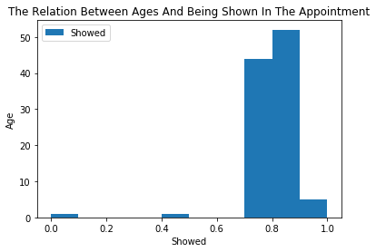

```python
# use a groupby function betwen Age and Showed to find the relation
df.groupby('Age')['Showed'].mean().plot(kind='hist');
# creat X and Y labels for the graph
plt.xlabel("Showed")
plt.ylabel("Age")
#create a title for the graph
plt.title("The Relation Between Ages And Being Shown In The Appointment")
# put the legend
plt.legend()
```

#### Question 1 summery :

At the End of analyzing each factor and its relation to predict if a patient will show up for their scheduled appointment.

gender and Alcoholism are not factors to predict if the patient will come or not based on the percentage of showing which equals to 50%/50%

### Q2-what are the ovarall number of patients showed in their appointments and who are not?

```
True     85307
False    25220
Name: Showed, dtype: int64
True     77.182046
False    22.817954
Name: Showed, dtype: float64
```

[figure not shown]

```python
# get the total count of patints showed and who are not showed
E7 = df.Showed.value_counts()
#calculate the percentage

percentage7 = E7 / E7.sum()*100
#print the results
print(E7)
print(percentage7)
#creat bar chart with size 5*6 to disply the counts
BarChart = E.plot.bar(figsize=(5,6));
#change the xticks labels
x=np.arange(2)
plt.xticks(x,('showed','not showed'))
# creat X,Y labels
plt.xlabel('Show status')
plt.ylabel('Number of patients')
# creat title for the graph
plt.title("The Total number of patints showed and who are Not Showed")
# enable the grid to easy the readability
plt.grid(True)
```

#### Question 2 summary :

There are 85307 patients show up in there appointment which equals to 77.18% of overall number of patients compared to 25220 which equal to 22.81% who are not

## Conclusions

#### result:

At the conclusion, the No_showappointment dataset is almost a clean data set just need some fixing and in my opinion i recommend this data set for the beginners in data analysing world.

There are a few numbers of patients that not show up in their appointment compared to who are showed

3- Scholarship

6- Gender

#### Limitation

1- The dataset is limited to only some few factors. the patients may have other factors for no show-up

2- There are 3540 patients who have wrong ages (0, -1)

## Submitting your Project

> Before you submit your project, you need to create a .html or .pdf version of this notebook in the workspace here. To do that, run the code cell below. If it worked correctly, you should get a return code of 0, and you should see the generated .html file in the workspace directory (click on the orange Jupyter icon in the upper left).

> Alternatively, you can download this report as .html via the **File** > **Download as** submenu, and then manually upload it into the workspace directory by clicking on the orange Jupyter icon in the upper left, then using the Upload button.

> Once you've done this, you can submit your project by clicking on the "Submit Project" button in the lower right here. This will create and submit a zip file with this .ipynb doc and the .html or .pdf version you created. Congratulations!

#### References

https://github.com/AmmarJawad/No-show-Medical-Appointments_Kaggle-dataset

https://github.com/samedhaa/investigating-a-dataset-no-show-appointments-udacity

https://github.com/kristenbee/appointment-no-show-exploration

```python
from subprocess import call
call(['python', '-m', 'nbconvert', 'Investigate_a_Dataset.ipynb'])
```

```
0
```